# ✅ Pipeline succeeded

Generated at 2026-10-19 20:58:17

## Core KPIs

| Registered users | **20,000** | INFO |
| --- | --- | --- |
| Deposit conversion | **42.1%** | OK |
| Trading conversion | **38.1%** | INFO |
| GMV | **$78,755,325.65** | INFO |
| Fee revenue | **$78,755.33** | INFO |
| Avg LTV 90d | **$3.23** | INFO |
| 90d churn | **62.2%** | ALERT |

## Insights & data-driven suggestions

1. **注册→首次入金转化率** — 当前 42.14%  
   建议：处于健康区间，保持监控
2. **入金→首笔交易转化率** — 当前 90.32%  
   建议：处于健康区间，保持监控
3. **90 天流失率** — 当前 62.21%  
   建议：高于阈值，建议对沉默用户启动召回
4. **漏斗最大漏损** — KYC→首次入金流失 5,724 人  
   建议：对已 KYC 未入金人群推送首充奖励 + 简化入金流程
5. **被末次点击低估的渠道** — affiliate 的马尔可夫贡献比末次点击高 2.2 个百分点  
   建议：预算评审改用马尔可夫/Shapley，避免只奖励最后一跳
6. **A/B 实验结果** — 实验组提升 36.72%，p=0.0000  
   建议：显著则全量，不显著则继续扩大样本或改版
7. **预算边际回报最高的渠道** — affiliate（每美元边际转化 0.238607）  
   建议：在弹性曲线拐点前优先加投该渠道，并设置边际回报下限
8. **LTV 模型选型** — LightGBM: Spearman=0.9914；BG/NBD + Gamma-Gamma: Spearman=0.7319  
   建议：以机器学习为主预测器，BG/NBD 的 P(alive) 作为流失判定特征

## Live dashboard

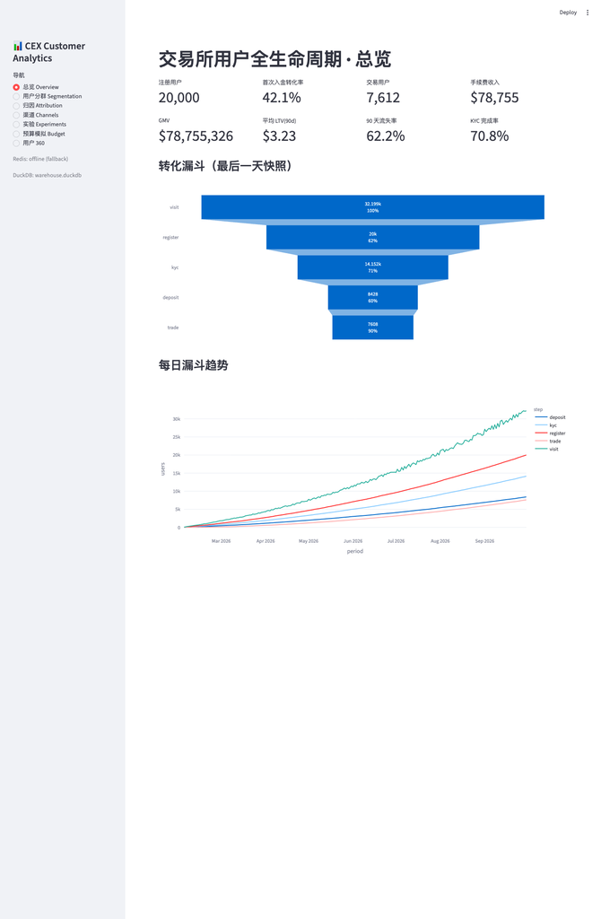

## Attribution

| channel | first_touch | last_touch | position_based | markov_chain | markov_vs_last_pct | stability_std | reconstruction_error |
| --- | --- | --- | --- | --- | --- | --- | --- |
| affiliate | 0.036664 | 0.038918 | 0.040775 | 0.060806 | 56.24 | 0.0039 | 0.0000 |
| brand_search | 0.120551 | 0.118059 | 0.117905 | 0.113903 | -3.52 | 0.0078 | 0.0001 |
| google_ads | 0.148078 | 0.151400 | 0.150506 | 0.154254 | 1.88 | 0.0062 | 0.0000 |
| kol | 0.067157 | 0.072734 | 0.072148 | 0.091122 | 25.28 | 0.0053 | 0.0000 |
| organic | 0.281799 | 0.268510 | 0.270867 | 0.218631 | -18.58 | 0.0085 | 0.0000 |
| referral | 0.175486 | 0.166706 | 0.167379 | 0.149860 | -10.11 | 0.0081 | 0.0001 |
| telegram | 0.074514 | 0.078073 | 0.077268 | 0.092474 | 18.45 | 0.0070 | 0.0000 |
| twitter | 0.095752 | 0.105600 | 0.103152 | 0.118950 | 12.64 | 0.0063 | 0.0001 |

## Channel performance

| channel | shapley_revenue | shapley_share | ad_spend | signups | depositors | revenue | roi | cpa | grade | inflation_flag |
| --- | --- | --- | --- | --- | --- | --- | --- | --- | --- | --- |
| organic | 20889.713561 | 0.2652 | 335895.44 | 4808 | 2602.0 | 26734.724959 | 0.079592 | 129.091253 | S | False |
| referral | 13495.534776 | 0.1714 | 332128.86 | 2736 | 1602.0 | 17078.242983 | 0.051421 | 207.321386 | S | False |
| google_ads | 11474.623714 | 0.1457 | 348593.51 | 3326 | 1248.0 | 10192.327280 | 0.029238 | 279.321723 | A | False |
| brand_search | 8845.375184 | 0.1123 | 328738.77 | 1954 | 1044.0 | 8599.153356 | 0.026158 | 314.883879 | A | False |
| twitter | 7967.434726 | 0.1012 | 310000.28 | 2380 | 730.0 | 6004.558604 | 0.019370 | 424.657918 | B | True |
| kol | 6195.428482 | 0.0787 | 325612.27 | 1791 | 461.0 | 4072.215961 | 0.012506 | 706.317289 | B | True |
| telegram | 6097.531712 | 0.0774 | 333767.13 | 1804 | 551.0 | 4520.965044 | 0.013545 | 605.747967 | C | True |
| affiliate | 3789.683498 | 0.0481 | 319154.31 | 1201 | 190.0 | 1553.137467 | 0.004866 | 1679.759526 | C | True |

## A/B test

| variant | n | conversions | cvr |
| --- | --- | --- | --- |
| control | 9942 | 976 | 0.0982 |
| treat | 10058 | 1350 | 0.1342 |